# Elastic Net Regression

# Regression

```r
require(dplyr)
require(caret)
require(glmnet)
```

```r
require(corrplot)
```

Let’s look at the `Hitters` dataset from the `ISLR` package to to get some more regression experience with **elastic net**

```r
data(Hitters, package = "ISLR")

Ytrain = Hitters %>%
  filter(!is.na(Hitters$Salary)) %>%
  select(Salary) %>%
  unlist(.)

XtrainDF = Hitters %>%
  filter(!is.na(Hitters$Salary)) %>%
  mutate('average' = Hits/AtBat, 'careerAvg' = CHits/CAtBat) %>%
  select(-Salary,-Division,-League,-NewLeague,-Hits,-AtBat, -CHits,-CAtBat) %>%
  mutate_all(as.numeric)

Xtrain = XtrainDF %>% as.matrix(.)
```

Let’s look at what we have

```r
dim(Xtrain)
```

```
## [1] 263  14
```

We can take a look at an estimate of the distribution of the supervisor:

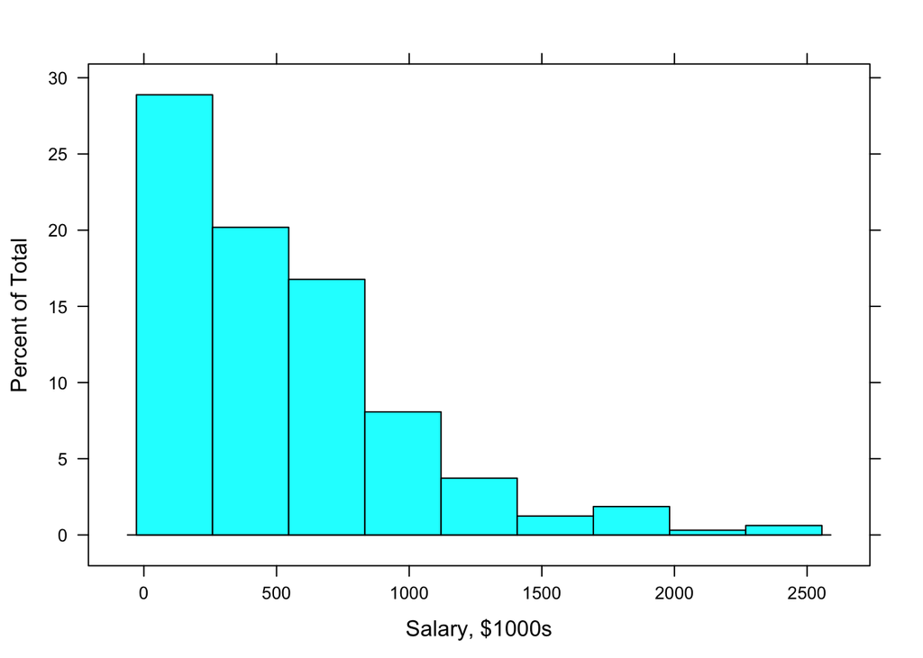

```r
histogram(Hitters$Salary, xlab = "Salary, $1000s")
```

This is likely going to be a case in which the supervisor (Salary) should be transformed.

Let’s look at the correlation structure of the features:

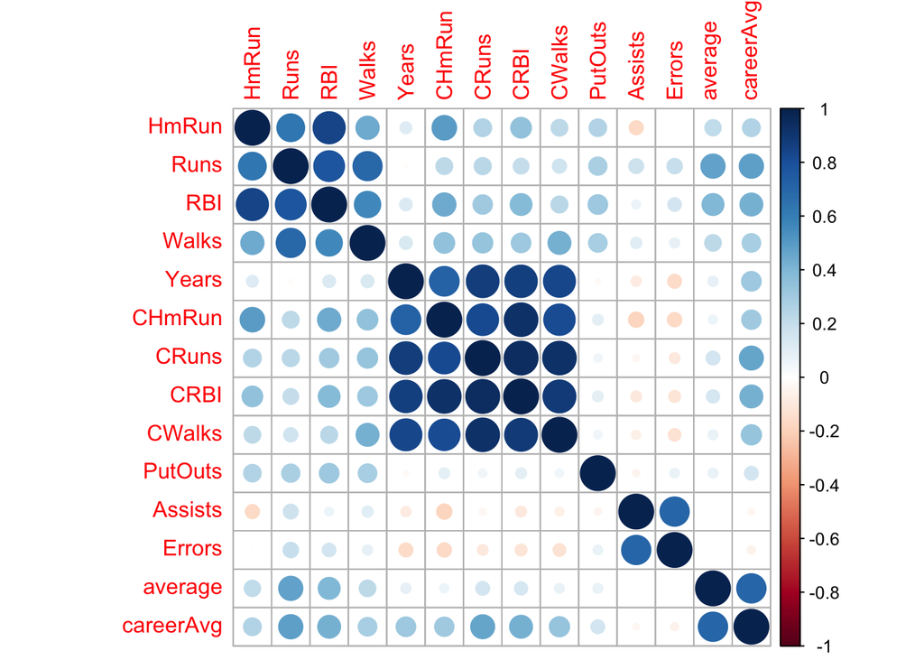

```r
Xcor = cor(Xtrain)
corrplot(Xcor)
```

Looks like we have some correlated features. Let’s estimate an elastic net model, and choose the tuning parameters alpha/lambda via minimizing K-fold CV.

Let’s specify a CV trainControl. We want K to be large enough so that the training set size is adequate.

```r
set.seed(1)
K    = 25
trainControl = trainControl(method = "cv", number = K)
```

We then use `train()` with `method = "glmnet"` which is actually fitting the elastic net.

```r
elasticOut = train(x = Xtrain, y = Ytrain,
                   method = "glmnet", trControl = trainControl)
```

Also note that we have allowed `caret` to choose the tuning parameter grid for us.

```r
elasticOut
```

```
## glmnet
##
## 263 samples
##  14 predictor
##
## No pre-processing
## Resampling: Cross-Validated (25 fold)
## Summary of sample sizes: 253, 252, 252, 253, 253, 252, ...
## Resampling results across tuning parameters:
##
##   alpha  lambda      RMSE      Rsquared   MAE
##   0.10    0.5105642  329.2519  0.5319112  239.3702
##   0.10    5.1056419  326.5762  0.5369033  236.7687
##   0.10   51.0564193  318.7743  0.5580973  228.8426
##   0.55    0.5105642  329.3641  0.5318933  239.3872
##   0.55    5.1056419  326.7381  0.5392871  235.3519
##   0.55   51.0564193  320.2810  0.5567186  229.9556
##   1.00    0.5105642  329.3562  0.5319866  239.2846
##   1.00    5.1056419  325.6467  0.5430704  234.1314
##   1.00   51.0564193  327.6936  0.5480139  237.2463
##
## RMSE was used to select the optimal model using the smallest value.
## The final values used for the model were alpha = 0.1 and lambda = 51.05642.
```

This is using an automatically allocated grid of alpha/lambda values, with alpha = `0.10`, `0.55`, and `1`. `caret` doesn’t use alpha = 0 by default in order to make sure the solution encourages some of the coefficients to be zero. Let’s look at the selected model. It is just as easy, in my opinion, to refit with glmnet

```r
glmnetOut      = glmnet(x = Xtrain, y = Ytrain, alpha = elasticOut$bestTune$alpha)
betaHat_glmnet = coef(glmnetOut, s = elasticOut$bestTune$lambda)
```

Let’s take a look at the residuals

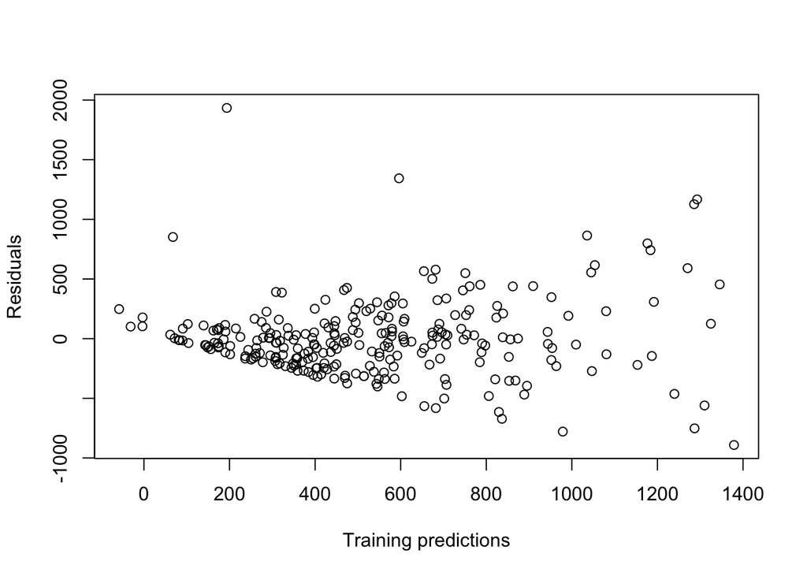

```r
YhatTrain_glmnet = predict(glmnetOut, Xtrain,  s = elasticOut$bestTune$lambda)
plot(YhatTrain_glmnet, Ytrain - YhatTrain_glmnet,
     xlab = 'Training predictions', ylab = 'Residuals')
```

A definite pattern in the residuals. Let’s take a look at transforming our supervisor

```r
YtrainLog  = log(Ytrain)
tuneGrid   = expand.grid('alpha'=c(0,.25,.5,.75,1),'lambda'=seq(0.001, .2, length.out = 30))
elasticOut = train(x = Xtrain, y = YtrainLog,
                   method = "glmnet", trControl = trainControl,
                   tuneGrid = tuneGrid)
elasticOut$bestTune
```

```
##    alpha    lambda
## 44  0.25 0.0902069
```

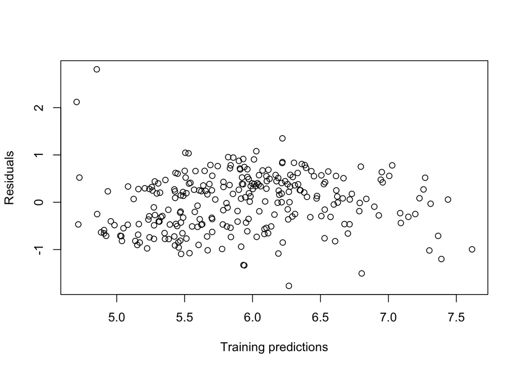

```r
glmnetOut        = glmnet(x = Xtrain, y = YtrainLog, alpha = elasticOut$bestTune$alpha)
betaHat_glmnet   = coef(glmnetOut, s = elasticOut$bestTune$lambda)
YhatTrain_glmnet = predict(glmnetOut, Xtrain,  s = elasticOut$bestTune$lambda)
plot(YhatTrain_glmnet, YtrainLog - YhatTrain_glmnet,
     xlab = 'Training predictions', ylab = 'Residuals')
```

These residuals look a lot better. Let’s have a look at those extreme observations:

```r
residuals = YtrainLog - YhatTrain_glmnet
largeResidual = order(residuals, decreasing = TRUE)[1:2]

Xtrain[largeResidual,]
```

```
##      HmRun Runs RBI Walks Years CHmRun CRuns CRBI CWalks PutOuts Assists
## [1,]     0    0   0     0     2      2     6    7      4      78     220
## [2,]     1    2   3     1     1      1     2    3      1     692      70
##      Errors   average careerAvg
## [1,]      6 0.0500000 0.2195122
## [2,]      8 0.2105263 0.2105263
```

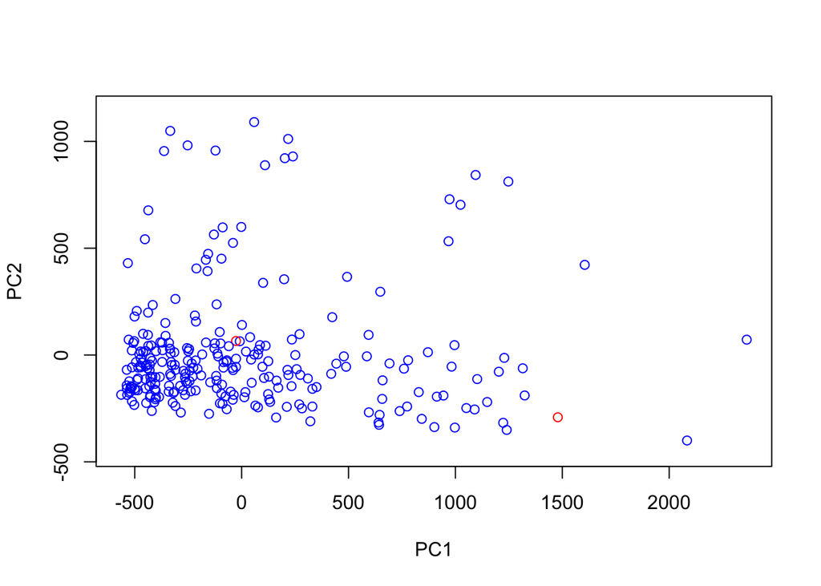

```r
pcaOut = prcomp(Xtrain)
colors = rep('blue',nrow(Xtrain))
colors[order(residuals)[1:2]] = 'red'
plot(pcaOut$x[,1:2],col = colors, asp=1)
```

Perhaps there is an extreme point, but not one of the large residuals. Let’s keep track of the extreme observation from the PCA plot (we won’t need it for this investigation, but it is good practice)

```r
largePCA = which.max(pcaOut$x[,1])
Xtrain[largePCA,]
```

```
##        HmRun         Runs          RBI        Walks        Years
##    0.0000000   15.0000000   25.0000000   30.0000000   24.0000000
##       CHmRun        CRuns         CRBI       CWalks      PutOuts
##  160.0000000 2165.0000000 1314.0000000 1566.0000000  523.0000000
##      Assists       Errors      average    careerAvg
##   43.0000000    6.0000000    0.2194093    0.3028535
```

Let’s take a look at what features were selected by the model

```r
betaHat_glmnet
```

```
## 15 x 1 sparse Matrix of class "dgCMatrix"
##                         1
## (Intercept)  3.1249648027
## HmRun        .
## Runs         0.0041600879
## RBI          0.0021834422
## Walks        0.0044399021
## Years        0.0435225711
## CHmRun       .
## CRuns        0.0003551256
## CRBI         0.0002120664
## CWalks       .
## PutOuts      0.0002350412
## Assists      0.0001785317
## Errors       .
## average     -1.0744427167
## careerAvg    7.4412190938
```

We can additionally look at the residuals as a function of each feature. Here, we are looking for obvious remaining structure or other oddities

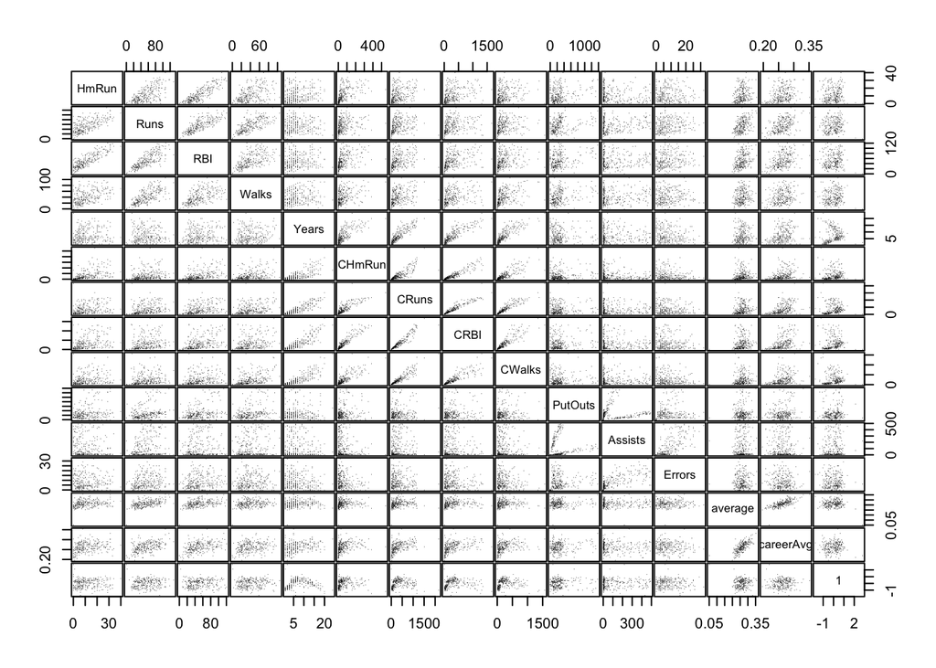

```r
pairs(cbind(Xtrain,residuals), cex=.1, pch=16, gap = .1)
```

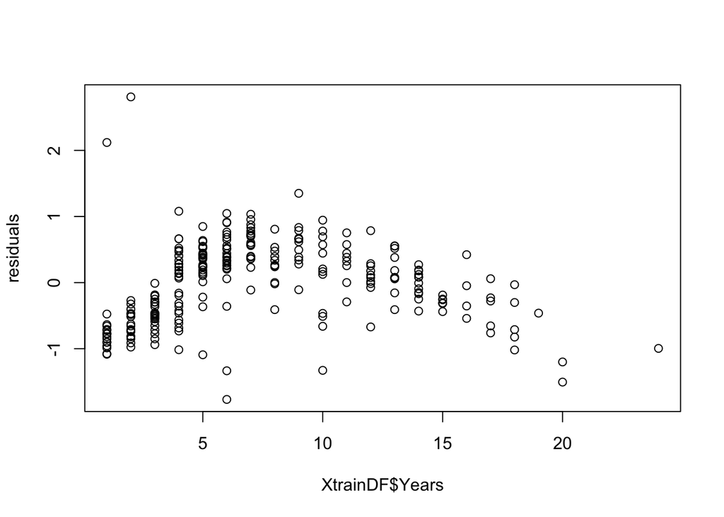

```r
plot(XtrainDF$Years, residuals )
```

There is a definite pattern here. Let’s go ahead and add a transformation to the model: years squared

```r
XtrainDF = XtrainDF %>%
  mutate('yearsSq' = Years^2)

Xtrain = XtrainDF %>% as.matrix(.)

tuneGrid   = expand.grid('alpha'=c(0,.25,.5,.75,1),
                         'lambda' = seq(0.0001, .2, length.out = 30))

elasticOut = train(x = Xtrain, y = YtrainLog,
                   method = "glmnet", trControl = trainControl,
                   tuneGrid = tuneGrid)
elasticOut$bestTune
```

```
##     alpha      lambda
## 122     1 0.006993103
```

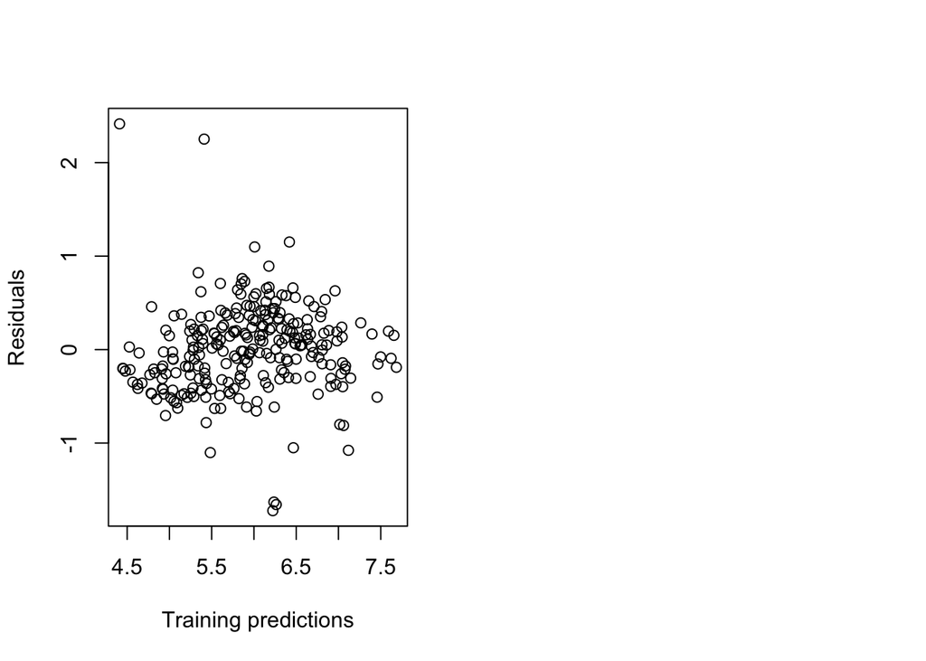

```r
glmnetOut        = glmnet(x = Xtrain, y = YtrainLog, alpha = elasticOut$bestTune$alpha)
betaHat_glmnet   = coef(glmnetOut, s = elasticOut$bestTune$lambda)
YhatTrain_glmnet = predict(glmnetOut, Xtrain,  s = elasticOut$bestTune$lambda)
par(mfrow= c(1,2))
residuals = YtrainLog - YhatTrain_glmnet
plot(YhatTrain_glmnet, residuals,
     xlab = 'Training predictions', ylab = 'Residuals')
```

```r
betaHat_glmnet
```

```
## 16 x 1 sparse Matrix of class "dgCMatrix"
##                         1
## (Intercept)  2.881270e+00
## HmRun        .
## Runs         2.906416e-03
## RBI          1.508523e-03
## Walks        2.012416e-03
## Years        2.658779e-01
## CHmRun       .
## CRuns        9.731831e-04
## CRBI         4.372782e-04
## CWalks       4.219556e-05
## PutOuts      3.397344e-04
## Assists      1.026344e-04
## Errors       .
## average     -5.515878e+00
## careerAvg    1.035804e+01
## yearsSq     -1.453158e-02
```

Hmm, unexpected the coefficient on average looks a bit fishy. Let’s take a closer look:

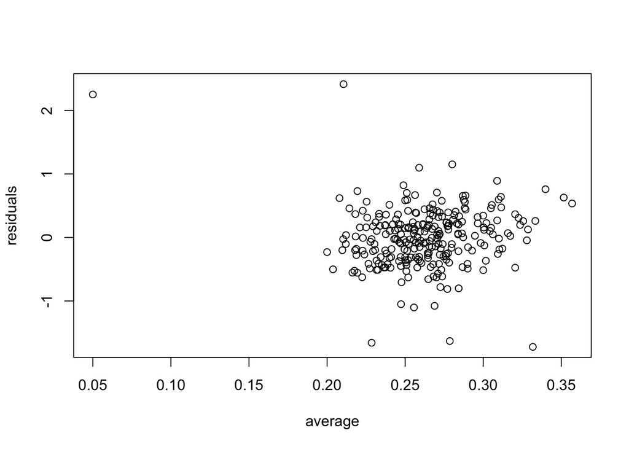

```r
plot(XtrainDF$average, residuals,xlab = 'average', ylab = 'residuals')
```

Clearly, there is an issue with this observation:

```r
Xtrain[which.min(XtrainDF$average),]
```

```
##       HmRun        Runs         RBI       Walks       Years      CHmRun
##   0.0000000   0.0000000   0.0000000   0.0000000   2.0000000   2.0000000
##       CRuns        CRBI      CWalks     PutOuts     Assists      Errors
##   6.0000000   7.0000000   4.0000000  78.0000000 220.0000000   6.0000000
##     average   careerAvg     yearsSq
##   0.0500000   0.2195122   4.0000000
```

This player has barely played, both this year and in his career. Let’s remove this observation and refit.

```r
XtrainDFremObs  = XtrainDF[-which.min(XtrainDF$average),]
YtrainLogRemObs = YtrainLog[-which.min(XtrainDF$average)]
XtrainRemObs    = XtrainDFremObs %>% as.matrix(.)

tuneGrid   = expand.grid('alpha'=c(0,.25,.5,.75,1),'lambda' = seq(0.0001, .2, length.out = 30))
elasticOut = train(x = XtrainRemObs, y = YtrainLogRemObs,
                   method = "glmnet", trControl = trainControl,
                   tuneGrid = tuneGrid)
elasticOut$bestTune
```

```
##     alpha      lambda
## 122     1 0.006993103
```

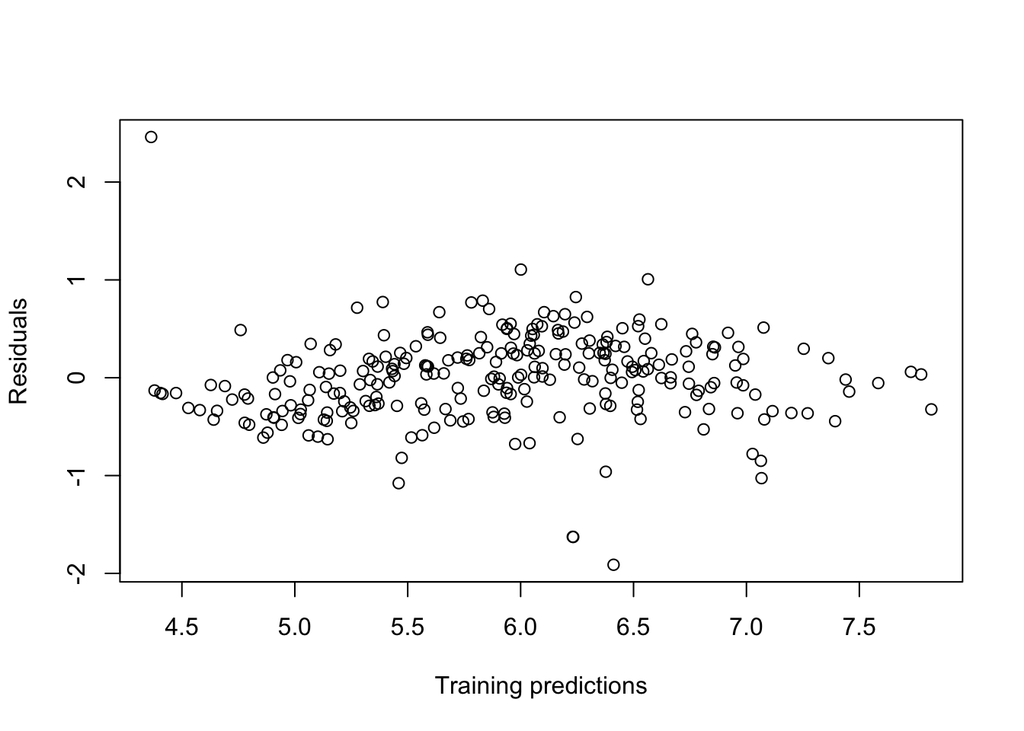

```r
glmnetOut        = glmnet(x = XtrainRemObs, y = YtrainLogRemObs, alpha = elasticOut$bestTune$alpha)
betaHat_glmnet   = coef(glmnetOut, s = elasticOut$bestTune$lambda)
YhatTrain_glmnet = predict(glmnetOut, XtrainRemObs,  s = elasticOut$bestTune$lambda)

residuals = YtrainLogRemObs - YhatTrain_glmnet
plot(YhatTrain_glmnet, residuals,
     xlab = 'Training predictions', ylab = 'Residuals')
```

```r
betaHat_glmnet
```

```
## 16 x 1 sparse Matrix of class "dgCMatrix"
##                         1
## (Intercept)  2.679684e+00
## HmRun        6.586939e-04
## Runs         1.814205e-03
## RBI          1.616623e-03
## Walks        3.080208e-03
## Years        2.618432e-01
## CHmRun       .
## CRuns        1.158212e-03
## CRBI         3.417918e-04
## CWalks       .
## PutOuts      3.746912e-04
## Assists      4.209159e-05
## Errors       3.041083e-06
## average     -1.087825e+00
## careerAvg    6.591751e+00
## yearsSq     -1.424290e-02
```

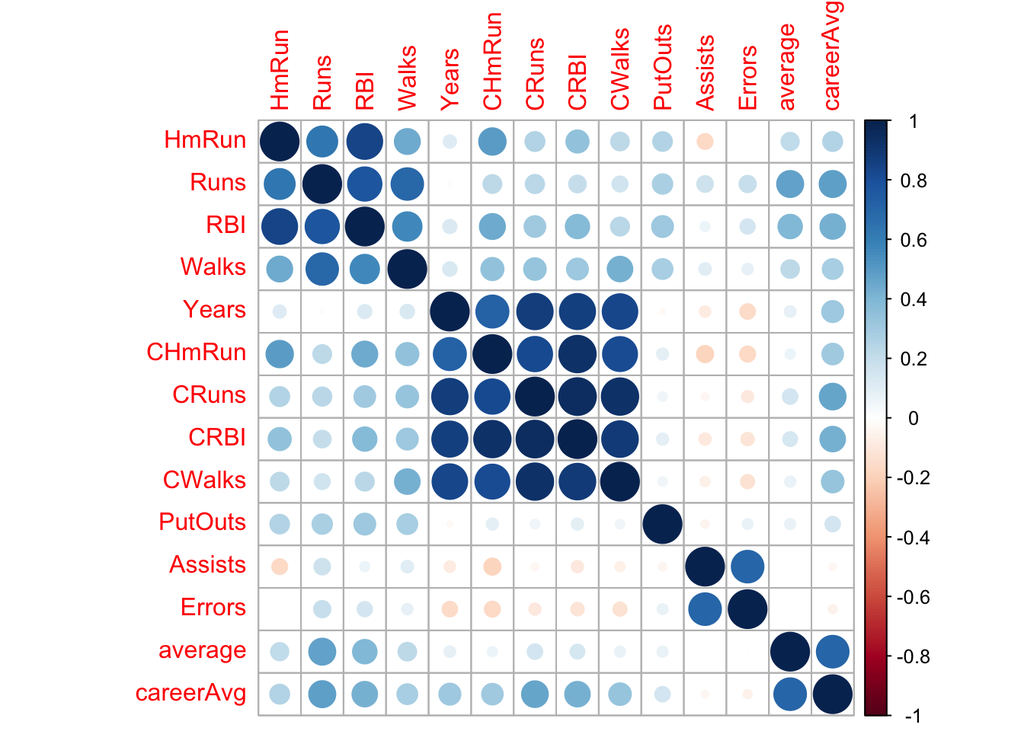

```r
corrplot(Xcor)
```

# Interpretation

We need to remember how to interpret these results. We have log transformed the supervisor, so this complicates the interpretation a bit. But, we can still say how each feature is associated with the supervisor **holding all other features constant**

This last part is crucial. The negative sign on the estimated coefficient for average indicates that holding all the other features constant (say, ability to score runs), we estimate a negative association between average and Salary.

This is an `observational` study. This means that we can only infer associate, not causation. This is such an important point that it is sometimes overlooked. Example:

Suppose I am a sports agent. I have a player who comes up to me and asks: should I try to hit for average or for runs? I turn to my handy coefficient estimates and I say: runs, of course. What is wrong with this statement?

# Predictions

```r
XtestDF = Hitters %>%
  filter(is.na(Hitters$Salary)) %>%
  mutate('average' = Hits/AtBat, 'careerAvg' = CHits/CAtBat) %>%
  select(-Salary,-Division,-League,-NewLeague,-Hits,-AtBat, -CHits,-CAtBat) %>%
  mutate_all(as.numeric) %>%
  mutate('yearsSq' = Years^2)

Xtest = XtestDF %>% as.matrix(.)
YhatTest_glmnet = predict(glmnetOut, Xtest,  s = elasticOut$bestTune$lambda)
```

We can convert these predictions to the original scale via exponentiation

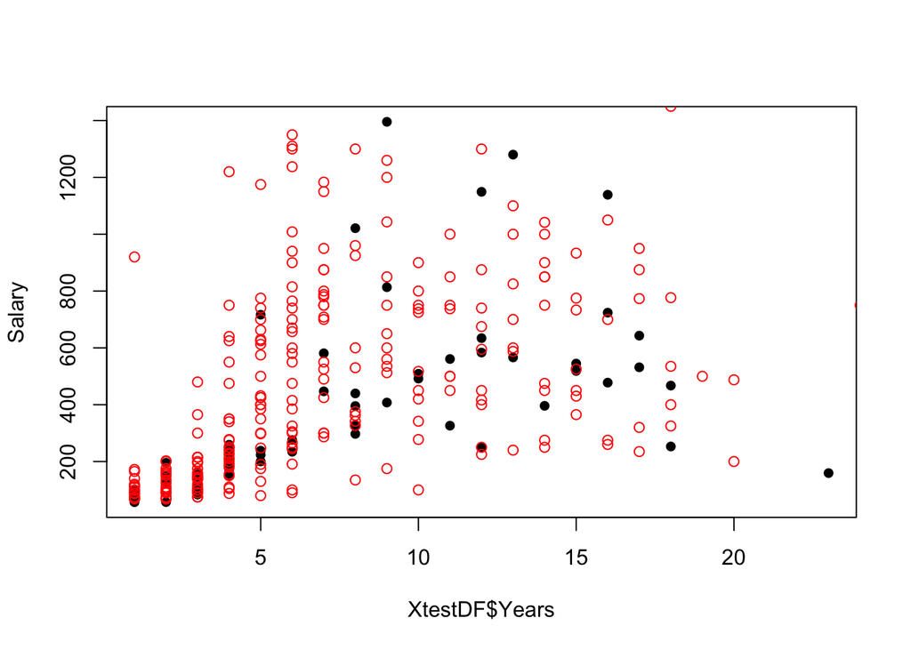

```r
plot(XtestDF$Years, exp(YhatTest_glmnet), pch = 16,
     ylab = 'Salary')
points(XtrainDF$Years, Ytrain, col = 'red')
```

These predictions seem reasonable (there isn’t any way to check; this is what it will be like in the real world!)